# Séries temporelles et Reproductibilité

Mandela M. Jacques - 111 224 204

Analyse et modélisation d’agroécosystèmes `-` 2019-04-01

# Directives du devoir

Les directives pour la réalisation de ce travail sont inscrites dans un fichier externe. Alors, elles pourront être consultées à partir du fichier Directives.md du dossier Directives.

# Question 1

## Création d’une série temporelle du CO2 à partir des données de `hawai.csv`

```r
# Charger le jeu de données
hawai <- read.csv("data/hawai.csv")

# Prétraitement du jeu de données
# Librairies requises
library(lubridate)
library(tidyverse)

hawai <- hawai %>%
  mutate(Date = time %>% date_decimal) %>% # Ajout d'une variable
  filter(Date < ymd(20010801)) %>%         # Limiter les données à juil. 2001
  mutate(Annee = Date %>% year())          # Ajout d'une variable numérique Année

hawai %>% head(5)
```

```
        time      CO2                Date Annee
  1 1958.167 316.1000 1958-03-02 20:00:01  1958
  2 1958.250 317.2000 1958-04-02 06:00:00  1958
  3 1958.333 317.4333 1958-05-02 16:00:00  1958
  4 1958.417 317.4333 1958-06-02 02:00:01  1958
  5 1958.500 315.6250 1958-07-02 12:00:00  1958
```

```r
# Serie temporelle et visualisation
# Librairies requises
library(forecast)
library(fpp2)
library(dygraphs)

hawai_ts <- ts(hawai %>%
                 select(CO2),  # Ne choisit que le CO2 atmosphérique
               start = c(hawai$Annee[1], 3), # Débuter en mars
               frequency = 12) # Fréquence de 12 pour les 12 mois de l'année

dygraph(hawai_ts, main = "Evolution de l'émission du co2 entre mars 1958 et juillet 2001") %>%
  dyRangeSelector(dateWindow = c("1958-03-01", "2001-07-31"))
```

[interactive chart not shown]

Les graphiques suivants réalisés avec les fonctions ggseasonplot et ggsubseriesplot de forecast permettent d’investiguer la serie temporelle et d’observer les fluctuations saisonières. A noter que le module cowplot développé par le professeur [Clauss O. Wilke](https://twitter.com/ClausWilke) pour la mise en forme des graphiques ggplot sera utilisé.

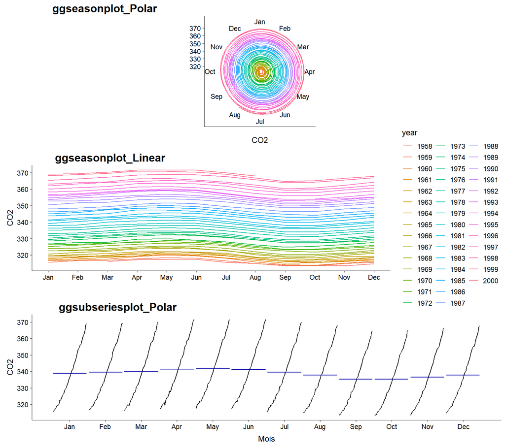

```r
# Librairie requise
library(cowplot)

theme_set(theme_cowplot(font_size = 10, font_family = " ", line_size = 0.1)) # cowplot change le theme
plot1 <- ggseasonplot(window(hawai_ts, 1958+2/12, 2001-5/12)) +
  labs(y="CO2", x = " ", title = " ")
plot2 <- ggseasonplot(window(hawai_ts, 1958+2/12, 2001-5/12), polar = TRUE) +
  labs(x = "CO2", title = " ") +
  theme(legend.position="none")
plot3 <- ggsubseriesplot(window(hawai_ts, 1958+2/12, 2001-5/12), polar = TRUE) +
  labs(x = "Mois", y = "CO2", title = " ")

plot_grid(plot2, plot1, plot3, ncol = 1, labels = c("ggseasonplot_Polar", "ggseasonplot_Linear", "ggsubseriesplot_Polar"))
```

## Analyse de l’autocorrélation

Maintenant, passons à l’analyse de l’autocorrélation sur la serie temporelle hawai_ts pour confirmer la forte tendance dont elle présente et les fluctuations saisonnières identifiées. Normalement, cette serie doit présenter sur son graphique d’autocorrélation un certain sommet à chaque saison tandis que les données de son graphiques de retardement se situeront très proche de la diagonale en raison de la forte tendance obervée à l’augmentation du CO2 atmosphérique en fonction du temps.

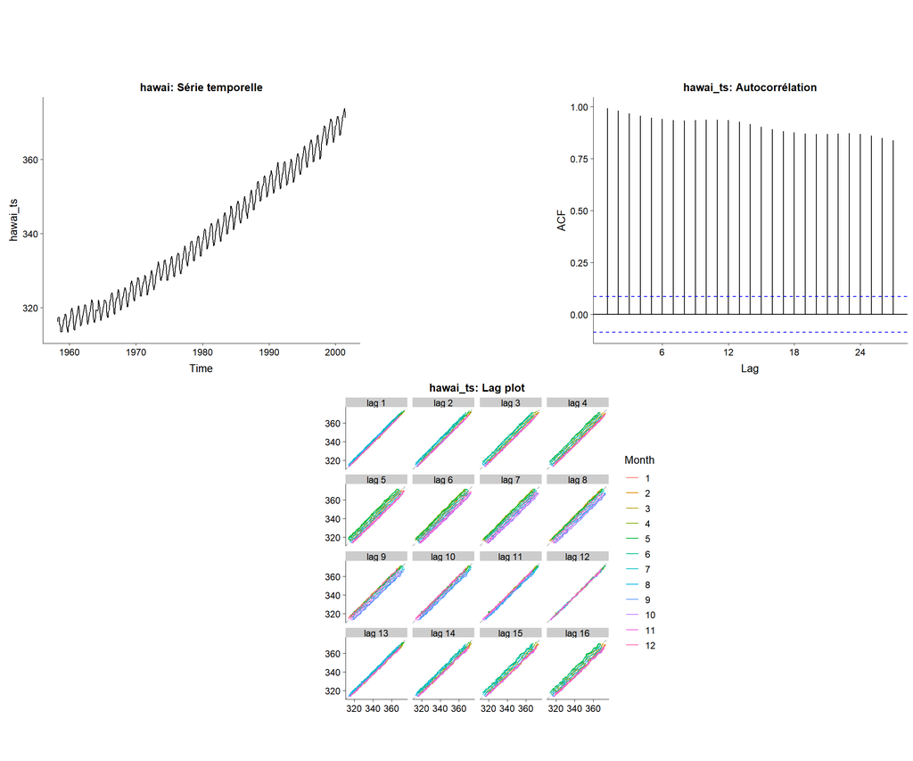

```r
# ggdraw est la fonction de base de cowplot pour combiner des graphiques
ggdraw() +
  # Transformation en objets graphiques et appel à la fonction draw_plot
  draw_grob(ggplotGrob(autoplot(hawai_ts) +
              ggtitle("hawai: Série temporelle")),
            x = -.30, y = .20, scale = 0.4) +
  # Ajout du graphique d'autocorrélation
  draw_grob(ggplotGrob(ggAcf(hawai_ts) + ggtitle("hawai_ts: Autocorrélation")),
            x = .30, y = .20, scale = 0.4) +
   # Ajout du lag plot
  draw_grob(ggplotGrob(gglagplot(hawai_ts) + ggtitle("hawai_ts: Lag plot")),
            x = 0.04, y = -.22, scale = 0.45)
```

## Signification statistique

Le test de signification statistique de la série temporelle sera réalisé avec la fonction `Box test` du package stats de base :

```r
Box <- Box.test(hawai_ts, lag = 20, type = "Ljung-Box") # lag définit le nombre de coef. d'autocor.
Box
```

```
    Box-Ljung test

  data:  hawai_ts
  X-squared = 9175.1, df = 20, p-value < 2.2e-16
```

Pour ce qui est de la signification statistique de la série temporelle, un `p-value` sensible égal à 0 suppose une probabilité quasiment nulle que cette série soit un bruit blanc. Le fait que la totalité des observations dépasse le seuil le confirme également.

# Question 2

## Fractionnement des données

Ce processus consiste à fractionner la série temporelle en deux parties. La première partie aura environ 70% des données et servira à l’entrainement du modèle tandis que l’autre partie pour tester le modèle obtenu.

```r
hawai_ts_train <- window(hawai_ts, start = 1958+2/12, end = (1958+2/12) + 0.7*length(hawai_ts)/12)
hawai_ts_test <- window(hawai_ts, start = (1958+2/12) + 0.7*length(hawai_ts)/12)
```

La proportion des données qui sera utilisée à l’entrainement du modèle commence en mars 1958 (`start = 1958+2/12`) et se termine en juillet 1988 (`end = (1958+2/12) + 0.7*length(hawai_ts)/12`). Ce qui représente en réalité 70.058 % des données.

# Question 3

## Création d’un modèle ETS

De nos jours, la modélisation de série temporelle représente un outil important pour la prévision (forecast) des évènements futurs. Plusieurs modèles ont été developpés durant les dernières décennies dont les modèles de lissage exponentiel simple (simple exponential smoothing (SES)) qui font des prévisions en fonction des données précédentes en les attribuant une pondération exponentielle qui diminue dans le temps. Ainsi, plus la date de mesure de la donnée est éloignée de la prévision, moins sera sa pondération.

Les algorithmes des modèles SES utilisés varient avec les caractéristiques de la série temporelle. Pour automatiser cette méthode, le modèle ETS a été conçu. Celui-ci vise l’optimisation en fonction de l’erreur (E), la tendance (T) et la saison (S). Entre 3 choix possibles pour la tendance et la saison et 2 pour l’erreur, la fonction [`ets de forecast`](https://www.rdocumentation.org/packages/forecast/versions/8.5/topics/ets) choisit la combinaison qu’elle juge meilleure en minimisant par défaut le critère d’information d’Akaike (AIC) ([Hyndman et Athanasopoulos (2018), chapitre 7.6](https://otexts.com/fpp2/estimation-and-model-selection.html)).

```r
# appel à la fonction ets
hawai_model_ets <- ets(hawai_ts_train)
hawai_model_ets
```

```
  ETS(M,Ad,M)

  Call:
   ets(y = hawai_ts_train)

    Smoothing parameters:
      alpha = 0.6729
      beta  = 0.028
      gamma = 1e-04
      phi   = 0.9763

    Initial states:
      l = 314.7929
      b = 0.0897
      s = 1.0017 0.9997 0.9971 0.9939 0.9909 0.9914
             0.9965 1.0024 1.0068 1.0086 1.0071 1.0039

    sigma:  0.001

       AIC     AICc      BIC
  1384.499 1386.476 1454.697
```

Alors, un ETS(M,Ad,M) a été choisi par la fonction ets. Cela signifie que l’erreur et la saison sont multiplicatives et la tendance est additive et adoucie. La methode amortie de Holt-Winters jugée la plus appropriée a été automatiquement utilisée parce qu’on utilise les arguments par defaut de la fonction ( [Voir plus sur la classification des SES](https://doi.org/10.1287/mnsc.15.5.311).)

## Visualisation du modèle ajusté par `ets`

Passons maintenant à la visualisation du modèle avec autoplot du package ggplot2

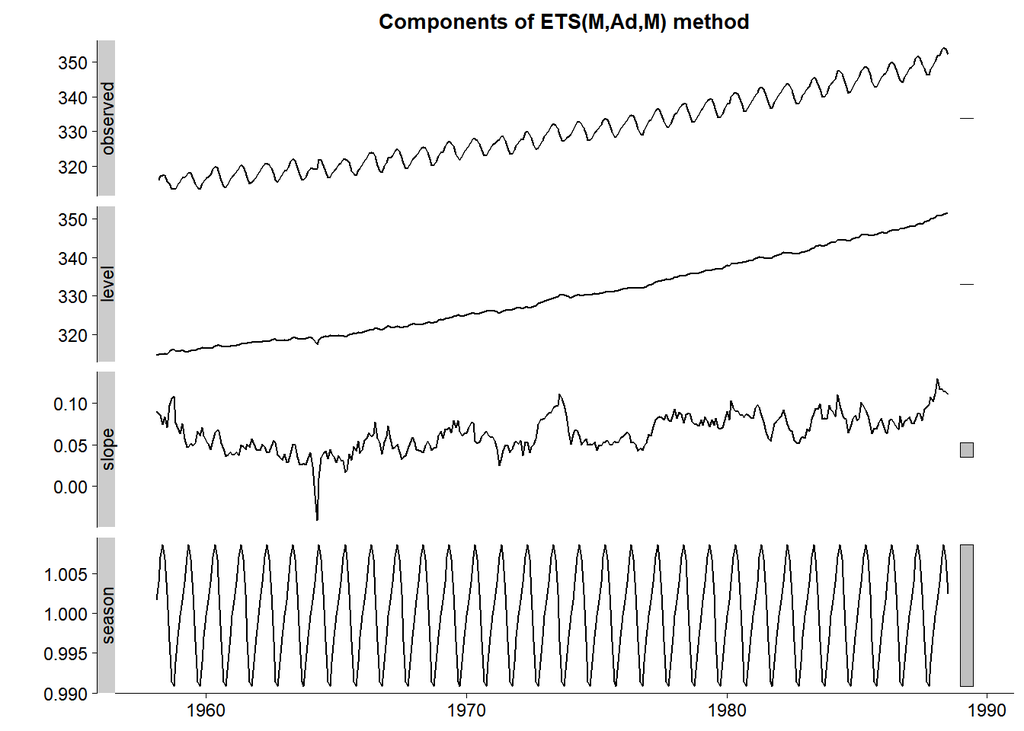

```r
autoplot(hawai_model_ets)
```

Au lieu de se baser sur la minimisation de la somme des erreurs au carré, la fonction ets de `forecast` s’est appuyée sur le maximum de vraisemblance pour définir les principaux paramètres du modèle. La vraisemblance étant la probabilité d’adéquation entre les données de la série temporelle et le modèle fixé. Il faut rappeler que la fonction ets ne produit que le modèle prévisionnel ajusté. Les variations de la pente, du niveau et de la saison sont présentés au graphique précédent.

## Projection de la prévision du CO2 atmosphérique

Une fois le modèle ajusté avec ets, il est facile de faire la prévision en faisant appel à la fonction forecast avec un horizon prévisionnel fixé:

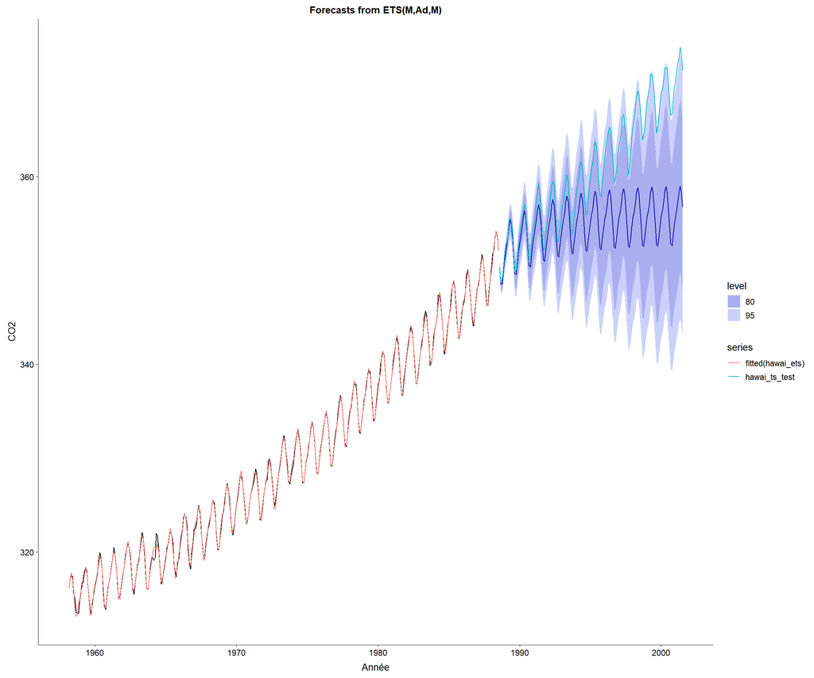

```r
hawai_ets <- hawai_model_ets %>% forecast(h = length(hawai_ts_test)) # h est l'horizon prévisionnel
hawai_ets %>% autoplot(xlab = "Année", ylab = "CO2" ) +
  autolayer(hawai_ts_test) +
  autolayer(fitted(hawai_ets))
```

Dans le graphique ci-dessus, les données test, représentées par la ligne verte, accusent un écart non négligeable par rapport à la prévision pour la période allant du mois d’aout 1988 à juillet 2001. Pour les deux niveaux considérés, l’intervalle prévisionnel varie considérablement et de ce fait, le CO2 atmosphérique peut augmenter au diminuer à tout moment selon la prévision faite par le modèle ets établie.

De plus, on remarque que le modèle a bien simuler les données d’entrainement. Les lignes rouges (données prédites) et noir (données d’entrainement) sont quasiment identiques. Cependant, à partir des années 2000, l’intervalle prévisionnel pour les 2 niveaux 80 et 95 n’inclut pas à certains points les valeurs réelles observées sur le CO2 atmosphérique. Ce qui présume que le modèle n’est pas performance à la prévision des données. Toutefois, l’évaluation de la précision du modèle et des résidus par les fonction accuracy et checkresidual permettra d’analyser en détails les résultats.

## Performance de la prévision

Comme il a été mentionné plus haut, le modèle se comporte bien à l’égard des données qui ont servi à son entrainement. Tous les principaux tests (RMSE, MAPE, MASE) présentent des valeurs d’erreurs proches de zéro pour l’entrainement du modèles. Par contre, ces erreurs augmentent rapidement avec les données de test. Les résultats de la performance du modèle qu’on juge à priori faible sont présentés ci-après :

```r
accuracy(hawai_ets, hawai_ts)
```

```
                       ME      RMSE       MAE        MPE       MAPE
  Training set 0.05620884 0.3295274 0.2495765 0.01676289 0.07583423
  Test set     5.84659700 7.5812534 5.8465970 1.59965590 1.59965590
                    MASE        ACF1 Theil's U
  Training set 0.2059554 0.002961553        NA
  Test set     4.8247256 0.982694962  5.907245
```

# Question 4

## Analyse des résidus

L’analyse des résidus se fera par l’observation des graphiques des résidus et suivant la valeur du p-value du test Ljung-Box. Tout cela peut se faire à l’appel de la fonction [checkresidual](https://www.rdocumentation.org/packages/forecast/versions/8.5/topics/checkresiduals) du package forcast.

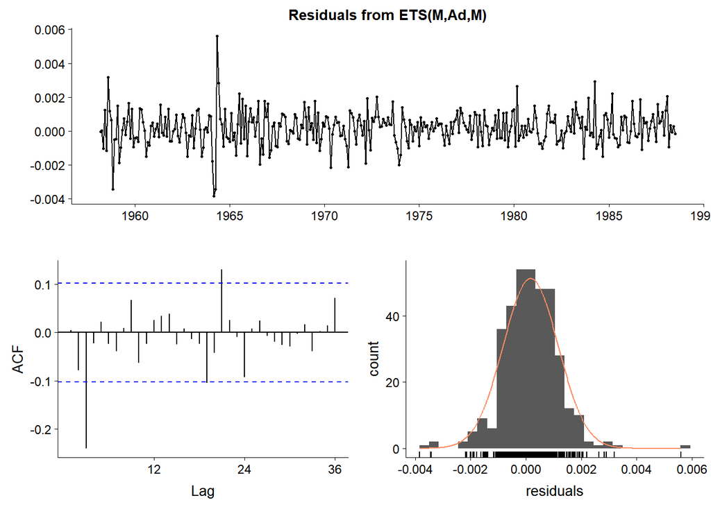

```
    Ljung-Box test

  data:  Residuals from ETS(M,Ad,M)
  Q* = 45.262, df = 7, p-value = 1.216e-07

  Model df: 17.   Total lags used: 24
```

```r
checkresiduals(hawai_model_ets)
```

Les résidus du modèle semblent être du bruit blanc en analysant la distribution des résidus en fonction du temps et les valeurs de l’ACF qui sont en majorité conprise dans l’intervalle de confiance de 95%. De plus,il se peut que les intervales prévisionnels du modèles soient valide puisque les résidus semble être normalement distribués (A vérifier avec les tests de kurtosis et shapito). Néanmoins, le résultat du test Ljung-Box avec un p-value quasiment nulle suppose qu’il est presqu’improbable que les résidus constituent un bruit blanc. Ainsi, le modèle n’a pas pu intercepter toutes les structures qui contient la série temporelle.

## Test de nomalité

```r
shapiro.test(residuals(hawai_model_ets))
```

```
    Shapiro-Wilk normality test

  data:  residuals(hawai_model_ets)
  W = 0.96812, p-value = 3.663e-07
```

```r
library("e1071")
kurtosis(residuals(hawai_model_ets), na.rm = TRUE)
```

```
  [1] 3.218524
```

# Question 5

## Commentaires et modèle alternatif

La plupart des commentaires perninents ont été intégrés dans le document au fur et à mesure qu’on traite les étapes précédentes. En effet, il convient de rappeller les aspects suivants pour mettre en doute la fiabilité du modèle. Avec une probabilité si faible (1.216e-07 - test de Ljung-Box) que les résidus soient générés par un bruit blanc et une inadéquation entre les données de test et leur prévision, Le modèle obtenu n’est pas assez fiable pour être adopté. Qui plus est, la non-normalité des résidus entraine l’invalidité des intervalles prévisionnels. Le graphique suivant est une prévision de la concentration du CO2 pour 2020.

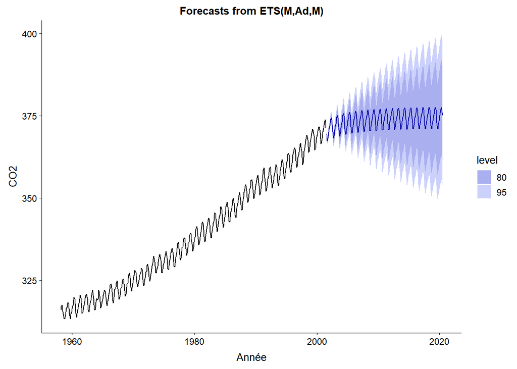

On a pu constater que la tendance à la hausse de la concentration du CO2 athmosphérique se stabiliserait dans le temps suivant le modèle ajusté par la fonction ets et que l’augmentation significative de l’intervalle de prévision permettrait des variations de concentration de CO2 de grande amplitude à la hausse ou à la baisse. Ainsi, il ne serait pas prudent de se baser sur un tel modèle pour la prise de décision.

Une alternative pour une meilleure modélisation serait la méthode intégrative d’auto-régression utilisant la moyenne mobile (ARIMA). Cette méthode est basée sur la recherche d’un nombre **p** d’autorégression entre les variables, **d** degré de première différentiation et **q** termes d’erreurs inpliquant dans la moyenne mobile. D’où l’appelation la formulation ARIMA(p, d, q). Dans ce cas, on aura un ARIMA(p, d, q)(P, D, Q)[x] puisque la saisonnalité de la série temporelles sera aussi affectée de trois paramètres et un terme qui désigne le nombre d’observations par an [x].

Ainsi, l’utilisation de la fonction auto.arima avec un horizon prévisionnel égale à la longueur de hawai_ts_test.

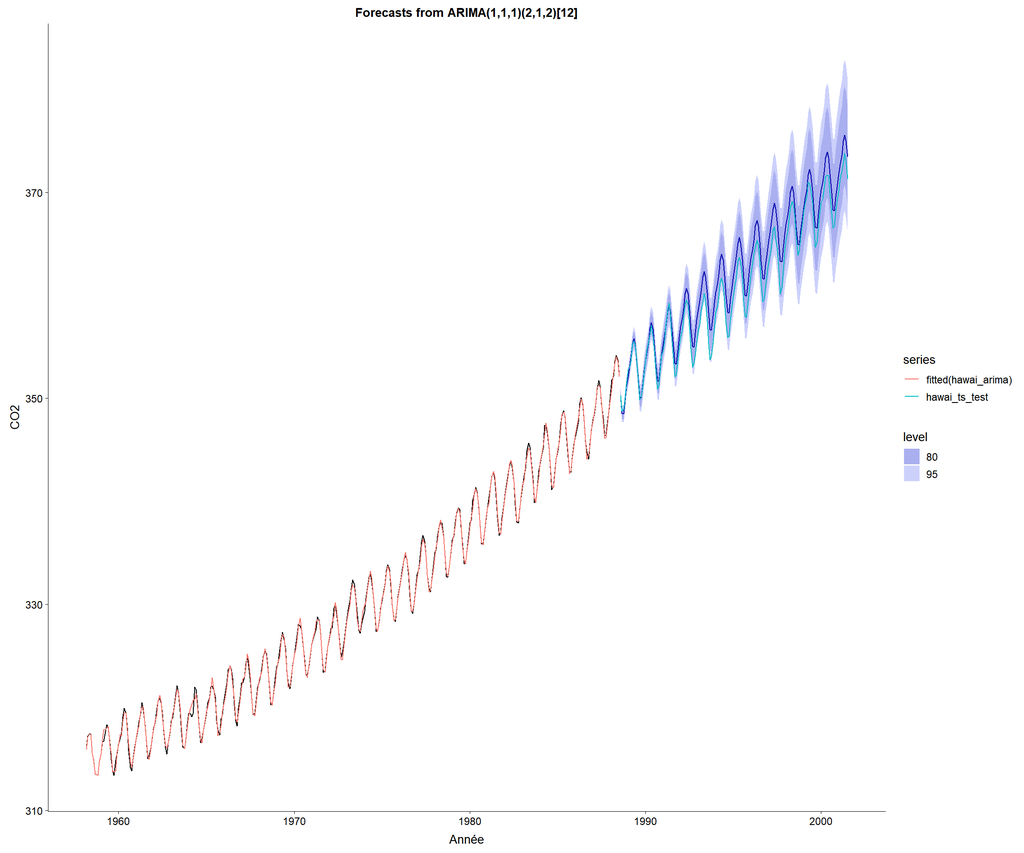

Visiblement, une meilleure prévision a été obtenue avec la fonction auto.arima qui ajuste un modèle arima(1,1,1)(2,1,2)[12]. Les données test sont relativement proches de la prévision faite par le modèle.

## Performance de la prévision

```r
accuracy(hawai_arima, hawai_ts)
```

```
                        ME     RMSE       MAE         MPE       MAPE
  Training set  0.03093385 0.331369 0.2547369  0.00906678 0.07733826
  Test set     -1.40303165 1.650990 1.4383602 -0.38758805 0.39759773
                    MASE        ACF1 Theil's U
  Training set 0.2102138 -0.01388877        NA
  Test set     1.1869628  0.92421528  1.306094
```

## Analyse des résidus

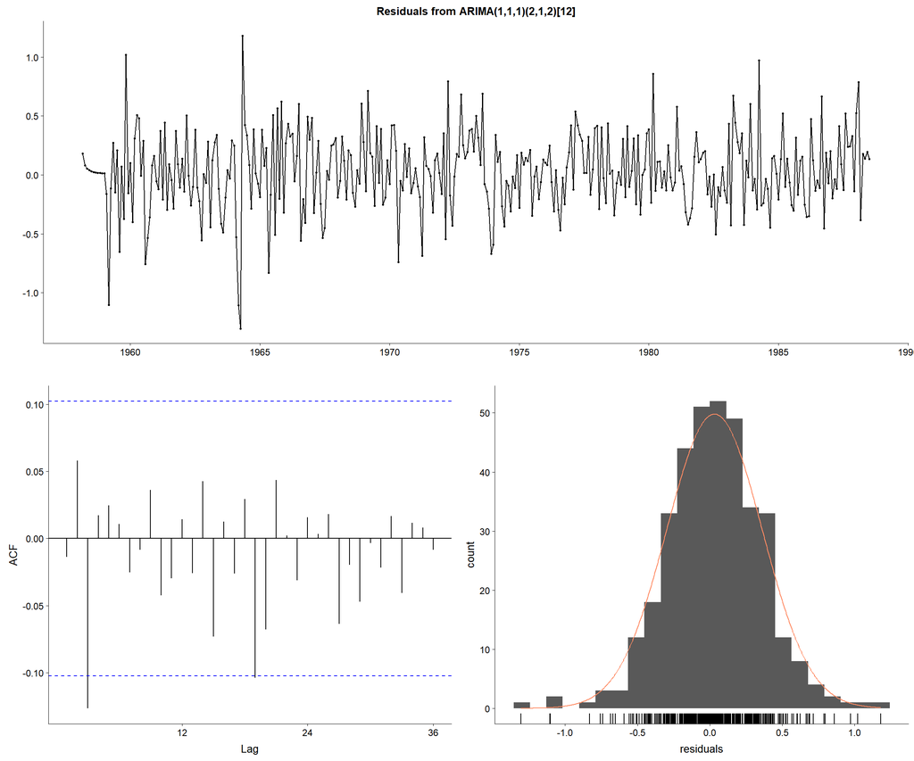

```
    Ljung-Box test

  data:  Residuals from ARIMA(1,1,1)(2,1,2)[12]
  Q* = 20.329, df = 18, p-value = 0.3146

  Model df: 6.   Total lags used: 24
```

```r
checkresiduals(hawai_model_arima)
```

Avec une probabilité de 31.46 %, il est alors fort probable que les résidus génèrent un bruit blanc. C’est un paramètre qui renseigne sur la bonne performance du modèle.

## Prévision du CO2 atmosphérique 2020

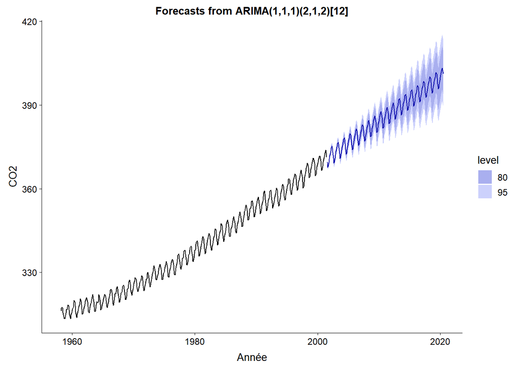

Le modèle arima est mieux adaptée à la prévision que la modèle ets. La tendance et les saisonnalité qui caractérisent la série temporelle hawai_ts sont conservées dans les prévisions et l’intervalle de prévision est plus resreint. Cela permettra des amplitudes de variation plus faibles (moins de variances entre les prévisions) et des données plus fiables.

# Conclusion

**forecast** constitue un puissant outil de modélisation des séries temporerelles. Elle est basée sur la même méthode des modèles d’apprentissage automatique en segmentant les données en une partie d’entrainement du modèle et une partie pour tester ce dernier. Deux fonctions très importants dans la prévision avec forecast sont ets et auto.arima. Elles sont basées sur le lissage exponentiel et l’analyse auto-régressive. Dans le cadre de ce travail, la fonction arima a permis de développer un modèle plus performant que celui réalisé avec ets. La forte tendance et la saisonnalité sont alors mieux capturer par la fonction auto.arima. Ce qui permet d’obtenir une distribution des résidus avec une probabilté de plus de 30 % pour qu’elle soit un bruit blanc.

&&&&&&&&&&&&&&&&&&&&&&&&&&&&&&&&&&&& FIN &&&&&&&&&&&&&&&&&&&&&&&&&&&&&&&&&&&&

Devoir réalisé par Mandela M. Jacques et présenté au Professeur Serge-Étienne Parent dans le cadre du cours “Analyse et modélisation d’agroécosystèmes”…